# p8105_hw1_lq2234

Lu Qiu

2023-09-16

### Problem 1

Load the packages:

```r
library(moderndive)
library(ggplot2)
library(tidyverse)
```

Load the `early_january_weather` dataset:

```r
data("early_january_weather")
```

Here is a short description of the dataset using inline R code:

- This dataset contains 15 variables, which are: origin, year, month, day, hour, temp, dewp, humid, wind_dir, wind_speed, wind_gust, precip, pressure, visib, time_hour.
- This dataset has 358 rows and 15 columns.
- The mean temperature is: 39.58.

Make a scatterplot of `temp` (y) vs `time_hour` (x):

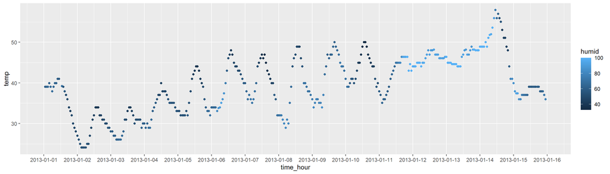

```r
ggplot(early_january_weather, aes(x = time_hour, y = temp)) + geom_point(aes(colour=humid)) + scale_x_datetime(date_breaks = "1 day")
```

Patterns that are apparent in this plot:

- The temperature shows an increasing trend from 2013-01-01 to 2013-01-15.
- Within a single day, the temperature is highest at noon and lower during the morning and night.
- Within a single day, the humidity is highest at night.
- The overall humidity is high from 2013-01-12 to 2013-01-15.

Export the scatterplot to the project directory using ggsave:

```r
ggsave("temp_time_scatter.png")
```

### Problem 2

Create a data frame comprised of:

- a random sample of size 10 from a standard Normal distribution
- a logical vector indicating whether elements of the sample are greater than 0
- a character vector of length 10
- a factor vector of length 10, with 3 different factor “levels”

```r
random_sample <- rnorm(10)
logical_vector <- random_sample > 0
character_vector <- c("Male", "Female", "Female", "Male", "Female", "Female", "Male", "Male", "Male", "Female")
factor_vector <- factor(rep(1:3, len = 10))
df <- data.frame(random_sample,
                 logical_vector,
                 character_vector,
                 factor_vector)
print(df)
```

```
##    random_sample logical_vector character_vector factor_vector
## 1      1.1537559           TRUE             Male             1
## 2     -0.9950992          FALSE           Female             2
## 3     -0.7145535          FALSE           Female             3
## 4      0.7808766           TRUE             Male             1
## 5      0.2428656           TRUE           Female             2
## 6      1.2270490           TRUE           Female             3
## 7     -0.9271572          FALSE             Male             1
## 8      0.9373546           TRUE             Male             2
## 9     -0.4511839          FALSE             Male             3
## 10    -0.4694879          FALSE           Female             1
```

The mean of the `random_sample` is 0.078442.  
The mean of the `logical_vector` is 0.5.  
The mean of the `character_vector` is NA.  
The mean of the `factor_sample` is NA.

The mean of `random_sample` and `logical_vector`can be calculated, while the mean of `character_vector` and `factor_sample` cannot be calculated.

```r
as.numeric(pull(df,2))
as.numeric(pull(df,3))
as.numeric(pull(df,4))
```

What happens, and why?

- Applying as.numeric to a logical vector converts it to a numeric vector where TRUE becomes 1 and FALSE becomes 0. This conversion helps explain what happens when trying to take the mean. Because the mean of a numeric vector containing 0s and 1s makes sense, the logical vector is coerced to a numeric vector when using mean().
- Applying as.numeric to a character vector does not provide meaningful results because characters cannot be directly converted to numeric values. R converts each character to NA, and taking the mean of NA values will result in NA.
- Applying as.numeric to a factor vector converts the factor levels to their underlying integer representation. Taking the mean of these integers does not have a meaningful interpretation, so the mean is also NA.